# Train Your Wearable Devices To Know Your Activity

Cong

August 4, 2016

Wearable devices such as Jawbone up, Nike FuelBand, Fitbi and Apple Watch are very popular. They use small sensors to collect a large amount of data about personal activities. Those data are promising for a wide range of usage: providing customized exercise monitoring, providing health advice, and so on. In this projects, I construct a supervised machine learning algorithm to predict the user’s activity from the data collecting by sensors in wearable devices.

## Fetch Data

To train the machine I use the Creative Commons license licensed WLE dataset. (Velloso, E.; Bulling, A.; Gellersen, H.; Ugulino, W.; Fuks, H. Qualitative Activity Recognition of Weight Lifting Exercises. Proceedings of 4th International Conference in Cooperation with SIGCHI (Augmented Human ’13) . Stuttgart, Germany: ACM SIGCHI, 2013.)

```r
TrainUrl <- "https://d396qusza40orc.cloudfront.net/predmachlearn/pml-training.csv"
TestUrl <- "https://d396qusza40orc.cloudfront.net/predmachlearn/pml-testing.csv"
TrainFileName <- "pml-training.csv"
TestFileName <- "pml-testing.csv"

if(!file.exists(TrainFileName)) download.file(TrainUrl, TrainFileName)
if(!file.exists(TestFileName)) download.file(TestUrl, TestFileName)

train_csv <- read.csv(TrainFileName, na.strings=c("NA","#DIV/0!",""))
test_csv <- read.csv(TestFileName, na.strings=c("NA","#DIV/0!",""))
dim(train_csv)
```

```
## [1] 19622   160
```

Now, we can see this is a large set of data with 160 features. But we can narrow down the features and only keep meaningful features, and this will help our algorithm run better.

## Clean Data

```r
library(caret)

# remove features with little variance, which won't help in predicting.
Useless_list <- nearZeroVar(train_csv)
train_csv <- train_csv[-Useless_list]

# remove the first feature, which is just enumerate.
train_csv <- train_csv[-c(1,2,3,4)]

# remove features whose NA is 60%.
NA_list <- NULL
N <- nrow(train_csv)
for( i in 1:length(train_csv))
{
    if(sum(is.na(train_csv[,i]))/N >=0.6) NA_list <- c(NA_list,-i)
}
train_csv <- train_csv[,NA_list]

set.seed(123456789)
train_index <- createDataPartition(train_csv$classe, p=0.6, list = F)
train <- train_csv[train_index,]
test <- train_csv[-train_index,]
```

## Model 1: Decision Trees

Implementing the Decision Trees method, and the predicting in test set data is good.

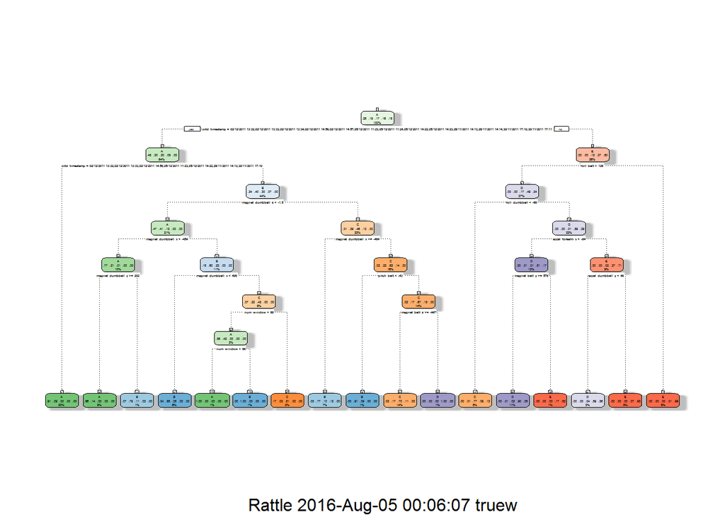

```r
library(rattle)
library(rpart)
set.seed(123456789)
model1 <- rpart(classe ~ ., data=train)

fancyRpartPlot(model1)
```

```r
predict_model1 <- predict(model1, test, type ="class")

Matrix_model1 <- confusionMatrix(predict_model1,test$classe)

Matrix_model1$table
```

```
##           Reference
## Prediction    A    B    C    D    E
##          A 2142  234    0    0    0
##          B   33 1107  134   59    0
##          C   57  164 1214  128   55
##          D    0   13   20 1046  186
##          E    0    0    0   53 1201
```

## Model 2: Random Forest

Implementing the Random Forest method, and the predicting in test set data is obviously better than decision trees method.

```r
library(randomForest)
set.seed(123456789)
model2 <- randomForest(classe ~ ., data=train)

predict_model2 <- predict(model2, test, type ="class")

Matrix_model2 <- confusionMatrix(predict_model2,test$classe)

Matrix_model2$table
```

```
##           Reference
## Prediction    A    B    C    D    E
##          A 2227    5    0    0    0
##          B    5 1513    9    0    0
##          C    0    0 1357    3    0
##          D    0    0    2 1283    5
##          E    0    0    0    0 1437
```

## Make a prediction

In the end, I am showing the prediction given by my trained algorithm.

```r
###### throw the un-necessary features as the training process ######
# remove features with little variance, which won't help in predicting.
test_csv <- test_csv[-Useless_list]
# remove the first feature, which is just enumerate.
test_csv <- test_csv[-c(1,2,3,4)]
# remove features whose NA is 60%.
test_csv <- test_csv[,NA_list]

###### predict ######
# change last column data class
test_csv <- test_csv[-length(test_csv)]
test_csv$classe <- test[1:nrow(test_csv),]
# by binding a new row and remove it, to ensure the same data class.
test_csv <- rbind(train[1,],test_csv)
test_csv <- test_csv[-1,]
predict_test <- predict(model2, test_csv, type ="class")
predict_test
```

```
##  2  3  4  5  6  7  8  9 10 11 12 13 14 15 16 17 18 19 20 21
##  B  A  B  A  A  E  D  B  A  A  B  C  B  A  E  E  A  B  B  B
## Levels: A B C D E
```